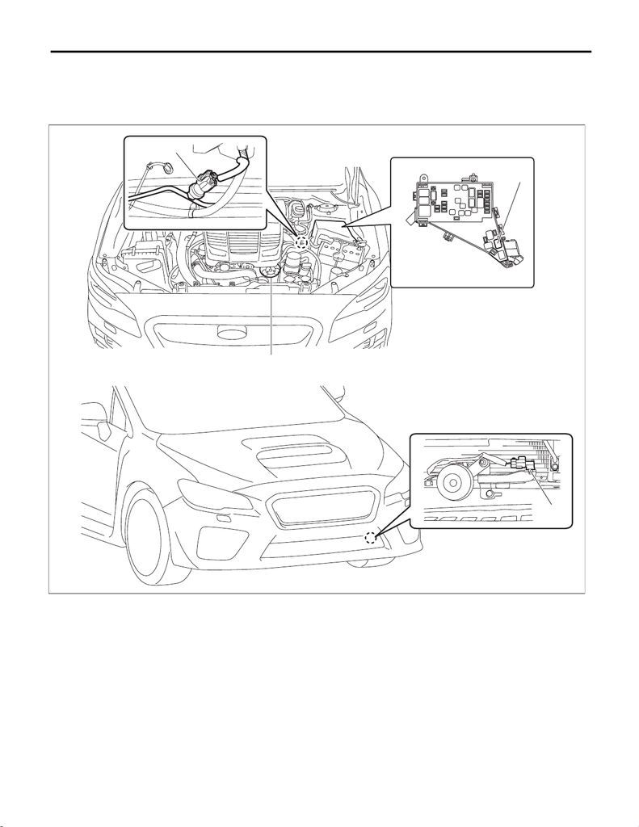

Electrical Component Location

HVAC SYSTEM (AUTO A/C) (DIAGNOSTICS)

3. Electrical Component Location

A: LOCATION

1. OUTSIDE VEHICLE

(1) A/C compressor (3) Pressure switch (4) Ambient sensor

(2) A/C relay

AC-03492

(1)

(4)

(2)

(3)

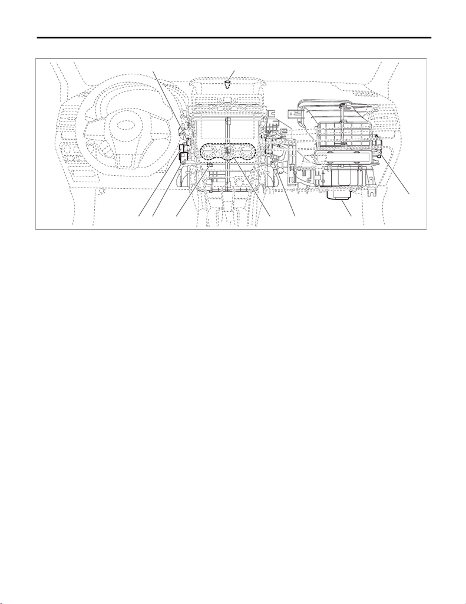

Electrical Component Location

HVAC SYSTEM (AUTO A/C) (DIAGNOSTICS)

2. COMPARTMENT

*1: Without left/right independent air conditioning function

*2: With left/right independent air conditioning function

(1) Air mix door actuator LH*2 (5) Intake door actuator (8) Air mix door actuator*1

(2) In-vehicle sensor (6) Mode door actuator (9) A/C control panel

(3) Evaporator sensor (7) Sunload sensor (10) Blower motor

(4) Air mix door actuator RH*2

AC-03480

(5)

(6)

(4),(8)

(3)

(1)

(10)

(9)